# My Multiple Logistic

#### Background

My question is derived from data collected from [The General Social Survey](http://sda.berkeley.edu/sdaweb/analysis/?dataset=gss12), in which repsondents were asked:

**In the past month, did you do any volunteer activity through organizations, that is donate your time and energy not for pay?**

I was curious about whether the age and gender of the respondents had any effect on whether or not they volunteered their time within the past month. Thus, my question is:

**Can age and gender be used to predict how likely a person is to take advantage of volunteer opportunities?**

## Model

The model used in this study is as follows:

$$P(Y_i = 1|\, \overbrace{x_{i1}}^{\text{age}}, \overbrace{x_{i2}}^{\text{gender}}) = \frac{e^{\beta_0 + \beta_1 x_{i1} + \beta_2 x_{i2}}}{1+e^{\beta_0 + \beta_1 x_{i1} + \beta_2 x_{i2} }} = \pi_i$$
Where $Y_i = 1$ denotes whether person $i$ volunteered in the past month, and $Y_i = 0$ that person $i$ did not volunteer. $x_{i1}$ represents the age of the individual, and $x_{i2}$ the gender.

$$H_0: \beta_1 = 0 \\
H_a: \beta_1 \neq 0$$

$$H_0: \beta_2 = 0 \\
H_a: \beta_2 \neq 0$$

Level of significance

$\alpha = .05$

**Gender** is represented by the following values:

| Response | Meaning |
| --- | --- |
| 1 | Male |
| 2 | Female |

**Age** responses range from 18 to 88, with 89 meaning 89 or older.

## Inspecting the Data

I thought it would be interesting to see a visual representation of those who volunteered according to gender and age:

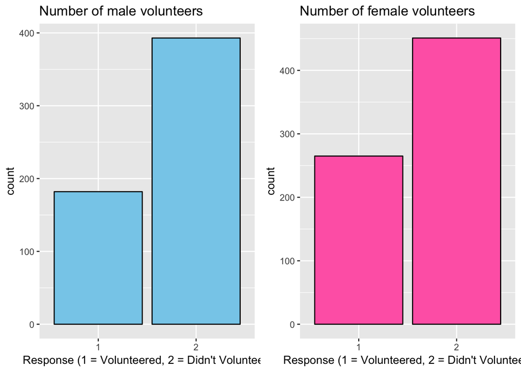

```r
plot_male <- ggplot(GSScMale, aes(x = as.factor(VOLMONTH))) +
  geom_bar(fill = c("skyblue",
                    "skyblue"),
           color = "black") +
  labs(title = "Number of male volunteers",
       x = "Response (1 = Volunteered, 2 = Didn't Volunteer)")

plot_female <- ggplot(GSScFemale, aes(x = as.factor(VOLMONTH))) +
  geom_bar(fill = c("hotpink",
                    "hotpink"),
           color = "black") +
  labs(title = "Number of female volunteers",
       x = "Response (1 = Volunteered, 2 = Didn't Volunteer)")

grid.arrange(plot_male, plot_female, ncol = 2)
```

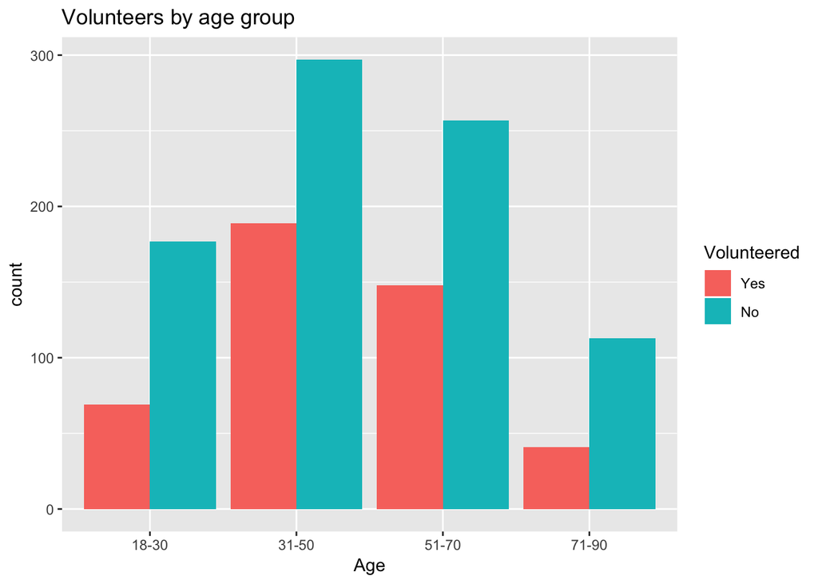

```r
GSSc$cat_age <- cut(GSSc$age, c(17,30, 50, 70, 90), labels = c('18-30', '31-50', '51-70', '71-90'))

ggplot(GSSc, aes(x = as.factor(cat_age), fill = as.factor(VOLMONTH))) +
  geom_bar(position = "dodge") +
  labs(x = 'Age', title="Volunteers by age group") +
  scale_fill_discrete(
    name="Volunteered",
    labels=c("Yes", "No")
)
```

## Results

The results of the logistic regression test can be seen as follows:

```r
GSSc.glm <- glm( (VOLMONTH == 1) ~ age + as.factor(sex), data=GSSc, family=binomial)
pander(summary(GSSc.glm))
```

|  | Estimate | Std. Error | z value | Pr(>\|z\|) |
| --- | --- | --- | --- | --- |
| **(Intercept)** | -0.7434 | 0.1827 | -4.07 | 4.708e-05 |
| **age** | -0.0005588 | 0.003365 | -0.166 | 0.8681 |
| **as.factor(sex)2** | 0.2388 | 0.1185 | 2.015 | 0.04393 |

(Dispersion parameter for binomial family taken to be 1 )

| Null deviance: | 1666 on 1290 degrees of freedom |
| --- | --- |
| Residual deviance: | 1662 on 1288 degrees of freedom |

This tells that age doesn’t have a significant impact on how likely a person is to volunteer (.8681 > .05), but gender does (.04393 < .05). The following chart suggests that females are consistently more likely than males to pursue volunteer activities across all age groups.

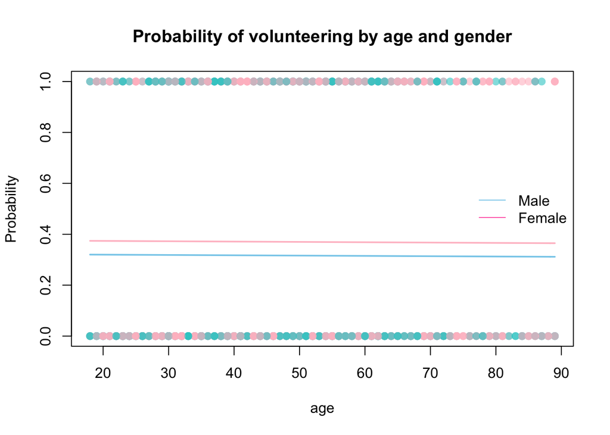

```r
c <- GSSc.glm$coefficients

palette(c(rgb(.2,.8,.8,0.6),rgb(1,0.75,.79,0.6)))

plot(VOLMONTH == 1 ~ age, data=GSSc, ylab="Probability", col=factor(sex), pch=16, cex=1.2, main="Probability of volunteering by age and gender")
legend("right", legend = c("Male", "Female"),
       lty = 1, col = c("skyblue", "hotpink"),
       bty = "n")

curve(exp(c[1] + c[2]*x)/(1 + exp(c[1] + c[2]*x)), add=TRUE, col='skyblue', lwd=1.8)

curve(exp(c[1] + c[3] + c[2]*x)/(1 + exp(c[1] + c[3] + c[2]*x)), add=TRUE, col='pink', lwd=1.8)
```

One important thing to note is the results of the goodness of fit test, telling us whether the logistic regresssion is a good fit for the data:

```r
pander(hoslem.test(GSSc.glm$y, GSSc.glm$fitted))
```

Hosmer and Lemeshow goodness of fit (GOF) test: `GSSc.glm$y, GSSc.glm$fitted`

| Test statistic | df | P value |
| --- | --- | --- |
| 16.56 | 8 | 0.03506 * |

## Interpretation

It would be interesting to further study if there are certain volunteer oppurtunities that attract a particular gender over another. Something that could add value to this study is which months respondents volunteered their time. Maybe a gender or an age group tends to volunteer differently in December than July, for example.